# Course Project Machine Learning

D.Dakhno

July 27, 2016

## Summary

Performance and accuracy of different predicting models were tested on the data coming from the Human Activity Recognition Project. The goal was to predict the outcome (a manner, in which the exercises was done) in twenty cases where it was unknown (original “testing” data set). The original “training” data set has been partitioned into training, testing and validation slices, the original “testing” used only one time for generation of the requested outcome. Six different non-linear predictive models were build using the training data set, parallel processing being used where applicable. After validating on the testing data set, the best by far accuracy was found for Random Forest, Stochastic Gradient Boosting and Quadratic Discriminant Analysis models. Model stacking was done at this basis, with the final validation of the models on the validation slice. The winner model has been used to predict the requested array of twenty outcomes. With respect to the reached accuracy level and it’s confidence interval, at least 19 of 20 predicted outcomes are expected to match with the original ones.

## Introduction

Data used in the project were gathered using devices such as Jawbone Up, Nike FuelBand, and Fitbit. Six probands with accelerometers on the belt, forearm, arm, and dumbbell were asked to perform barbell lifts correctly and incorrectly in 5 different ways. More information is available from the website here: http://groupware.les.inf.puc-rio.br/har (see the section on the Weight Lifting Exercise Dataset).

**The goal of the project is to predict the manner in which they did the exercise.**

This is the “classe” variable in the training set. Other variables can be used as predictors.

## Restrictions and conventions

With respect to the existing restrictions (max. 2000 words and 4 figures), the main part of the executed source code stays away from the HTML report, though it is available in the Rmarkdown version.

## General setup and downloading the data

Pre-partitioned training and test data were downloaded using following links:  
https://d396qusza40orc.cloudfront.net/predmachlearn/pml-training.csv  
https://d396qusza40orc.cloudfront.net/predmachlearn/pml-testing.csv

## Explorative data analysis

```r
dim(training)
[1] 19622   160
```

One issue to deal with is, that the outcomes in the training dataset is apparently ordered by variable *classe*:

```r
range(which(training$classe=="A", arr.ind = T))
[1]    1 5580
range(which(training$classe=="B", arr.ind = T))
[1] 5581 9377
```

…so we should riffle the cards explicitly as a precaution.

```r
set.seed(654321)
spatt <- sample(1:dim(training)[1],replace = FALSE)
training <- training[spatt,]
num_na <- sapply(training,function(x) sum(is.na(x)))
num_na_range <- range(num_na[num_na > 0])
```

Variable “classe” is outcome, whereas user_name could is possible predictor (individual traits could contribute to the outcome). Other variables are the measurements from the fitness gadgets. The number of the measured variables as possible predictors is 155 (though, timestamps will be ignored), but 100 of them has from 19216 to 19622 missing values, out of 19622 possible. There is no reliable imputing method available, so we exclude them from the further analysis and validation.

```r
set.seed(654321)
spatt <- sample(1:dim(training)[1],replace = FALSE)
num_na <- sapply(training,function(x) sum(is.na(x)))
num_na_range <- range(num_na[num_na > 0])
training <- training[,num_na < num_na_range[1]]
ultima_ratio <- testing[,num_na < num_na_range[1]]
```

#### Principal component analysis of the training data set

Performed for the data exploration, PCA shows the first seven principal components explaining about 90% of the total variance in dataset. PCA could bring the speed up of two times for the training function. According to the preliminary benchmarks, a common controversy execution performance vs. prediction accuracy has been shown.

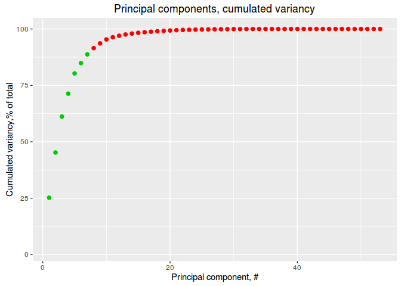

## Prediction study design

```r
dim(training)
[1] 11776    56
dim(testing)
[1] 2366   56
dim(validation)
[1] 2364   56
table(sapply(training,class))

 factor integer numeric
      3      26      27
```

There are five possible levels of outcome.

```r
table(training$classe)

   A    B    C    D    E
3348 2279 2054 1930 2165
```

## Building models

Linear and generalized linear regression models in default setup doesn’t really work with the factor outcome, so we will use different, non-linear models for prediction. With respect to the discrete nature of the outcome, assessment of the in sample error is performed using accuracy of prediction against the training set (manual control with *confusionTable()*) and reported by model itself (as *max(modFit\$results\\$Accuracy)*).  
Parallel processing is used for the sake of performance, allowing to test more model types and methods.

```
        Library          Model Method   Metric trContrMeth. number repeats
1:        rpart Classification  rpart Accuracy           cv      5       1
2:          gbm Classification    gbm Accuracy           cv      5       1
3:         klaR Classification     nb Accuracy           cv      5       1
4: randomForest Classification     rf Accuracy           cv      5       1
5:         MASS Classification    lda Accuracy           cv      5       1
6:         MASS Classification    qda Accuracy           cv      5       1
```

### Assessment of the in sample accuracy

Assessment of the in sample accuracy will be performed using the function *confusionMatrix()*, as well as the requested through the model fit itself.

```
   Count      Library Method   Metric Accuracy,model Accuracy,cT
1: 11776        rpart  rpart Accuracy         0.5227   0.5003397
2: 11776         MASS    lda Accuracy         0.7429   0.7471128
3: 11776         klaR     nb Accuracy         0.7500   0.7601053
4: 11776         MASS    qda Accuracy         0.9130   0.9214504
5: 11776          gbm    gbm Accuracy         0.9857   0.9940557
6: 11776 randomForest     rf Accuracy         0.9958   1.0000000
   Exec.time,sec.
1:         19.048
2:          2.865
3:        208.858
4:          1.525
5:        281.309
6:        617.195
```

At this moment, the top-3 leading methods are Random Forest, Generalized Boosted Regression and Quadratic Discriminant Analysis, with accuracy of respective 1, 0.9940557 and 0.9214504. Fast ideal accuracy should not be overestimated thinking on possible overfitting.

## Validating models on the testing dataset

### Assessment of out of sample accuracy

Assessment is done on the testing data set.

```
   Count Method  Accuracy AccuracyLower AccuracyUpper AccuracyPValue
1:  2366  rpart 0.5038039     0.4834520     0.5241464      0.9521705
2:  2366    lda 0.7383770     0.7201676     0.7559944      0.0000000
3:  2366     nb 0.7734573     0.7560462     0.7901887      0.0000000
4:  2366    qda 0.9213863     0.9098006     0.9319153      0.0000000
5:  2366    gbm 0.9945055     0.9906226     0.9970713      0.0000000
6:  2366     rf 1.0000000     0.9984421     1.0000000      0.0000000
```

```r
gc()
##            used  (Mb) gc trigger  (Mb) max used  (Mb)
## Ncells  1875840 100.2    3205452 171.2  3205452 171.2
## Vcells 13505035 103.1   39674475 302.7 80060219 610.9
```

The better models offer better accuracy at the price of interpretability and scalability

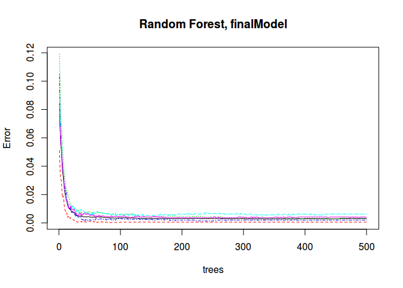

..compared to the moderately accurate methods like rpart.

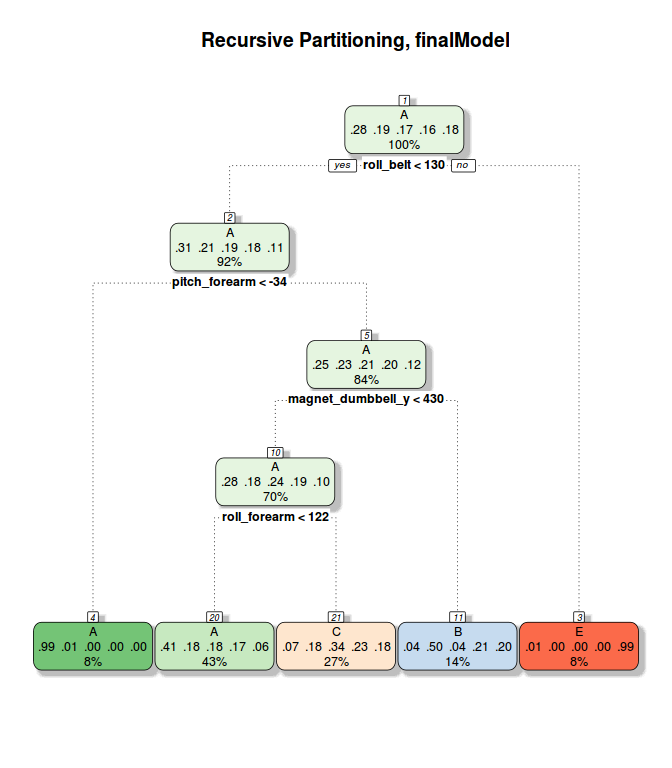

### Combining classifiers

It is known, that combining classifiers may improve accuracy. We stack the three most informative predictive methods to prove this, combining their predicted values and using the the set of the modelling methods, except for both discriminant analysis methods (they bring error with the already high colinear stacked primary outcomes),

```
    Count      Method  Accuracy AccuracyLower AccuracyUpper AccuracyPValue
 1:  2366       rpart 0.5038039     0.4834520     0.5241464   9.521705e-01
 2:  2366 combi-rpart 0.6652578     0.6458361     0.6842696   3.309693e-06
 3:  2366         lda 0.7383770     0.7201676     0.7559944   0.000000e+00
 4:  2366          nb 0.7734573     0.7560462     0.7901887   0.000000e+00
 5:  2366         qda 0.9213863     0.9098006     0.9319153   0.000000e+00
 6:  2366    combi-nb 0.9919696     0.9874878     0.9951584   0.000000e+00
 7:  2366         gbm 0.9945055     0.9906226     0.9970713   0.000000e+00
 8:  2366          rf 1.0000000     0.9984421     1.0000000   0.000000e+00
 9:  2366   combi-gbm 1.0000000     0.9984421     1.0000000   0.000000e+00
10:  2366    combi-rf 1.0000000     0.9984421     1.0000000   0.000000e+00
```

```r
gc()
##            used  (Mb) gc trigger  (Mb) max used  (Mb)
## Ncells  2070196 110.6    3205452 171.2  3205452 171.2
## Vcells 14264389 108.9   39674475 302.7 80060219 610.9
```

The combination of predictors brings not really the accuracy gain , as the best accuracy of stand-alone prediction is really top-notch (accuracy combined 1 vs. 1 for Random Forest). The shortlist for the final model evaluation and selection of the winner includes three best elementary methods, used to build predictors for three best methods for combined data. We give the chance to all of them.

```r
shortlist
[1] "qda"       "gbm"       "rf"        "combi-nb"  "combi-gbm" "combi-rf"
```

## Final models evaluation and selection of the winner

For this step we are using the validation slice. We use only the original data, stacked outcomes and the already built models from the shortlist.

[output not shown]

Unexpected, the maximal accuracy on the validation data set is not lower, than on testing. The winner is a method, based on the combination of the primarly generated outcomes.

## Generating the requested output array

Following the results of the validation, the method of choice at the final stage is Random Forest, analizing stack of primary predictors and offering accuracy of 1. It is used to generate the requested array of twenty outcomes. We secure the result comparing it to that of Random Forest.

```r
   modFit <- modelList[[best_method_val]]
   col1 <- predict(modelList[shortlist[1]],newdata = ultima_ratio)
   col2 <- predict(modelList[shortlist[2]],newdata = ultima_ratio)
   col3 <- predict(modelList[shortlist[3]],newdata = ultima_ratio)

   combiFinal <- data.frame(classe=as.factor(rep(x="UNKNOWN",20)),
                                   col1=col1,
                                   col2=col2,
                                   col2=col2
                                   )
   colnames(combiFinal) <- c("classe","col1","col2", "col3")
   prdCombi <- predict(modFit, combiFinal)
   modFit <- modelList["rf"]
   prdRF <- predict(modFit, ultima_ratio)
   identical(prdCombi,prdRF$rf)
## [1] TRUE
   #print(prdCombi ;-)
   stopCluster(cl)
```